# Mixed model lab #2 (GLMMs)

Ben Bolker

20:07 24 June 2023

Licensed under the [Creative Commons attribution-noncommercial license](http://creativecommons.org/licenses/by-nc/3.0/). Please share & remix noncommercially, mentioning its origin.

```r
library(lme4)
library(glmmTMB)
library(aods3)
library(glmmTMB)
library(broom.mixed)
library(dotwhisker)
```

# Model simplification examples

- keep maximal model?
- remove terms until non-singular?
- find minimum-AIC model?
- find minimum non-singular AIC model?

Barr et al. (2013); Bates et al. (2015); Matuschek et al. (2017)

## CBPP data

Starting again with the “basic” CBPP model:

```r
data("cbpp",package="lme4")
g1 <- glmer(incidence/size~period+(1|herd),
      data=cbpp,
      weights=size,
      family=binomial)
```

What happens if we try to fit the *maximal* model?

```r
g1max <- update(g1,.~.-(1|herd) + (period|herd))
```

```
## Error: number of observations (=56) < number of random effects (=60) for term (period | herd); the random-effects parameters are probably unidentifiable
```

Use `glmerControl()` to override the warning …

```r
g1max <- glmer(incidence/size~period+(period|herd),
      data=cbpp,
      weights=size,
      family=binomial,
      control=glmerControl(check.nobs.vs.nRE="warning"))
```

```
## Warning: number of observations (=56) < number of random effects (=60) for term
## (period | herd); the random-effects parameters are probably unidentifiable
```

```
## Warning in checkConv(attr(opt, "derivs"), opt$par, ctrl = control$checkConv, :
## Model failed to converge with max|grad| = 0.014498 (tol = 0.002, component 1)
```

```r
VarCorr(g1max)
```

```
##  Groups Name        Std.Dev. Corr
##  herd   (Intercept) 0.96471
##         period2     1.39959  -0.894
##         period3     1.97383  -0.504  0.837
##         period4     0.90544  -0.811  0.464 -0.096
```

```r
eigen(VarCorr(g1max)[[1]])$values
```

```
## [1] 5.906126e+00 1.699171e+00 2.518033e-05 2.936276e-06
```

Look at `?convergence` …

```r
af <- allFit(g1max)
```

```
## bobyqa : [OK]
## Nelder_Mead : [OK]
## nlminbwrap : [OK]
## optimx.L-BFGS-B : [OK]
## nloptwrap.NLOPT_LN_NELDERMEAD : [OK]
## nloptwrap.NLOPT_LN_BOBYQA : [OK]
```

(warnings/messages suppressed)

We can use `summary(af)` to compare all of these fits.

- `(period|herd)` vs. `(1|period/herd)` ([positive] compound symmetry)

$$(\textrm{intercept}, \textrm{slope}) =
\textrm{MVN}\left(\boldsymbol 0,
\left[
\begin{array}{cccc}
\sigma^2_{\{h|1\}} & . & . & . \\
\sigma_{\{h|1\},\{h|p_{21}\}} &
\sigma^2_{\{h|p_{21}\}} & . & . \\
\sigma_{\{h|1\}, \{h|p_{31}\}} &
\sigma_{\{h|p_{21}\},\{h|p_{31}\}} &
\sigma^2_{\{h|p_{31}\}} & . \\
\sigma_{\{h|1\} ,\{h|p_{41}\}} &
\sigma_{\{h|p_{21}\},\{h|p_{41}\}} &
\sigma_{\{h|p_{31}\},\{h|p_{41}\}} &
\sigma^2_{\{h|p_{41}\}}
\end{array}
\right]
\right)$$
(=$(n(n+1))/2 = (4\times 5)/2 = 10$ parameters) vs.
$$\left[
\begin{array}{cccc}
\sigma^2 & . & . & . \\
\rho \sigma^2 & \sigma^2 & . & . \\
\rho \sigma^2 & \rho \sigma^2 & \sigma^2 & . \\
\rho \sigma^2 & \rho \sigma^2 & \rho \sigma^2 & \sigma^2 \\
\end{array}
\right]$$
where $\sigma^2 = \sigma^2_{\{b|1\}}+\sigma^2_{\{herd:period|1\}}$, $\rho = \sigma^2_{\{b|1\}}/\sigma^2$ (=2 parameters; $\rho$ must be >0)

```r
g1cs <- update(g1max,
               . ~ . - (period|herd) + (1|herd/period))
```

The latter model is called a **compound symmetry** model, i.e. the variances are the same and the covariances/correlations between all pairs are the same. This is a slightly restricted version of compound symmetry, because (the way we have set it up) only non-negative correlations are possible. In general, this is a good way to simplify variation of factor effects across groups when there are many levels of the factor, and when it is plausible to treat the factor levels as exchangeable. The simplified (CS) model works fine in this example - but is equivalent (in this case, where there is only one observation per herd per period) to observation-level random effects!

## gopher tortoise data

```r
load("../../data/gopherdat2.RData")
Gdat$obs <- factor(seq(nrow(Gdat)))
```

Our desired maximal model would be something like

```r
glmer(shells~prev+offset(log(Area))+(1|year)+(1|Site)+(1|obs),
      family=poisson,data=Gdat)
```

```
## boundary (singular) fit: see help('isSingular')
```

```
## Generalized linear mixed model fit by maximum likelihood (Laplace
##   Approximation) [glmerMod]
##  Family: poisson  ( log )
## Formula: shells ~ prev + offset(log(Area)) + (1 | year) + (1 | Site) +
##     (1 | obs)
##    Data: Gdat
##      AIC      BIC   logLik deviance df.resid
##  90.0359  97.0419 -40.0179  80.0359       25
## Random effects:
##  Groups Name        Std.Dev.
##  obs    (Intercept) 0.000e+00
##  Site   (Intercept) 1.089e-05
##  year   (Intercept) 1.163e-01
## Number of obs: 30, groups:  obs, 30; Site, 10; year, 3
## Fixed Effects:
## (Intercept)         prev
##    -3.52835      0.02107
## optimizer (Nelder_Mead) convergence code: 0 (OK) ; 0 optimizer warnings; 1 lme4 warnings
```

or

```r
glmmTMB(shells~prev+offset(log(Area))+(1|year)+(1|Site),
      family=nbinom2,data=Gdat)
```

```
## Formula:          shells ~ prev + offset(log(Area)) + (1 | year) + (1 | Site)
## Data: Gdat
##       AIC       BIC    logLik  df.resid
##  90.03588  97.04186 -40.01794        25
## Random-effects (co)variances:
##
## Conditional model:
##  Groups Name        Std.Dev.
##  year   (Intercept) 1.164e-01
##  Site   (Intercept) 9.103e-09
##
## Number of obs: 30 / Conditional model: year, 3; Site, 10
##
## Dispersion parameter for nbinom2 family (): 3.92e+07
##
## Fixed Effects:
##
## Conditional model:
## (Intercept)         prev
##    -3.52838      0.02107
```

Problems …

ended up with this …

```r
gmod_lme4_L <- glmer(shells~prev+offset(log(Area))+factor(year)+(1|Site),
      family=poisson,data=Gdat,
      control=glmerControl(optimizer="bobyqa",
                           check.conv.grad=.makeCC("warning",0.05)))
```

```
## boundary (singular) fit: see help('isSingular')
```

(see [ecostats example](https://bbolker.github.io/mixedmodels-misc/ecostats_chap.html))

## Arabidopsis data

Try full model (except use only a simple fixed effect for the top-level region, `reg`, which has only 3 levels):

```r
load("../../data/Banta.RData")
t0 <- system.time(
    mp1 <- glmer(total.fruits ~ nutrient*amd +
                 reg + rack + status +
                 (amd*nutrient|popu)+
                 (amd*nutrient|gen),
             data=dat.tf,
             family="poisson")
)
```

```
## boundary (singular) fit: see help('isSingular')
```

Inspect for singularity/overdispersion:

```r
eigen(VarCorr(mp1)$gen)$values
```

```
## [1] 2.16111878 0.45199361 0.12339611 0.02321676
```

```r
eigen(VarCorr(mp1)$popu)$values
```

```
## [1] 1.666746e+00 1.066821e-01 7.014628e-08 1.629630e-09
```

```r
deviance(mp1)/df.residual(mp1) ## !!
```

```
## [1] 23.33935
```

```r
aods3::gof(mp1)
```

```
## D  = 13910.25, df = 596, P(>D) = 0
## X2 = 15079.55, df = 596, P(>X2) = 0
```

Add observation-level random effect (switch optimizer to BOBYQA)

```r
dat.tf$obs <- 1:nrow(dat.tf)
t1 <- system.time(
    mp1X <- update(mp1,
                   . ~. + (1|obs),
                   control=glmerControl(optimizer="bobyqa"))
)
```

```
## boundary (singular) fit: see help('isSingular')
```

```r
t2 <- system.time(
    mp1g <- glmmTMB(total.fruits ~ nutrient*amd +
                        reg + rack + status +
                        (amd*nutrient|popu)+
                        (amd*nutrient|gen)+
                        (1|obs),
                    data=dat.tf,
                    family="poisson")
)
```

Better (5), although `glmmTMB` doesn’t handle singular fits quite as gracefully …

```r
mp1X2 <- update(mp1X,
                . ~ . - (amd*nutrient|popu)
                - (amd*nutrient|gen)
                + (amd+nutrient|popu)
                + (amd+nutrient|gen))
```

```
## boundary (singular) fit: see help('isSingular')
```

Ugh, looks even worse …

```r
VarCorr(mp1X2)
```

```
##  Groups Name        Std.Dev. Corr
##  obs    (Intercept) 1.419975
##  gen    (Intercept) 0.482349
##         amdclipped  0.036182 -1.000
##         nutrient8   0.312491 -1.000  1.000
##  popu   (Intercept) 0.434531
##         amdclipped  0.075765 1.000
##         nutrient8   0.138279 1.000  1.000
```

Use `lmer_alt` to split factor variable into separate terms …

```r
mp1X3 <- afex::lmer_alt(total.fruits ~ nutrient*amd +
                            reg + rack + status +
                            (amd*nutrient||popu)+
                            (amd*nutrient||gen)+
                            (1|obs),
                        data=dat.tf,
                        family="poisson")
```

Strip down further:

```r
mp1X4 <- update(mp1X2,
                . ~ . - (amd+nutrient|popu)
                - (amd+nutrient|gen)
                + (nutrient|popu)
                + (1|gen))
```

```
## boundary (singular) fit: see help('isSingular')
```

Still correlation=+1, reduce further:

```r
mp1X5 <- afex::lmer_alt(total.fruits ~ nutrient*amd +
                            reg + rack + status +
                            (1|gen)+
                            (1+nutrient||popu)+
                            (1|obs),
                        data=dat.tf,
                        family="poisson")
```

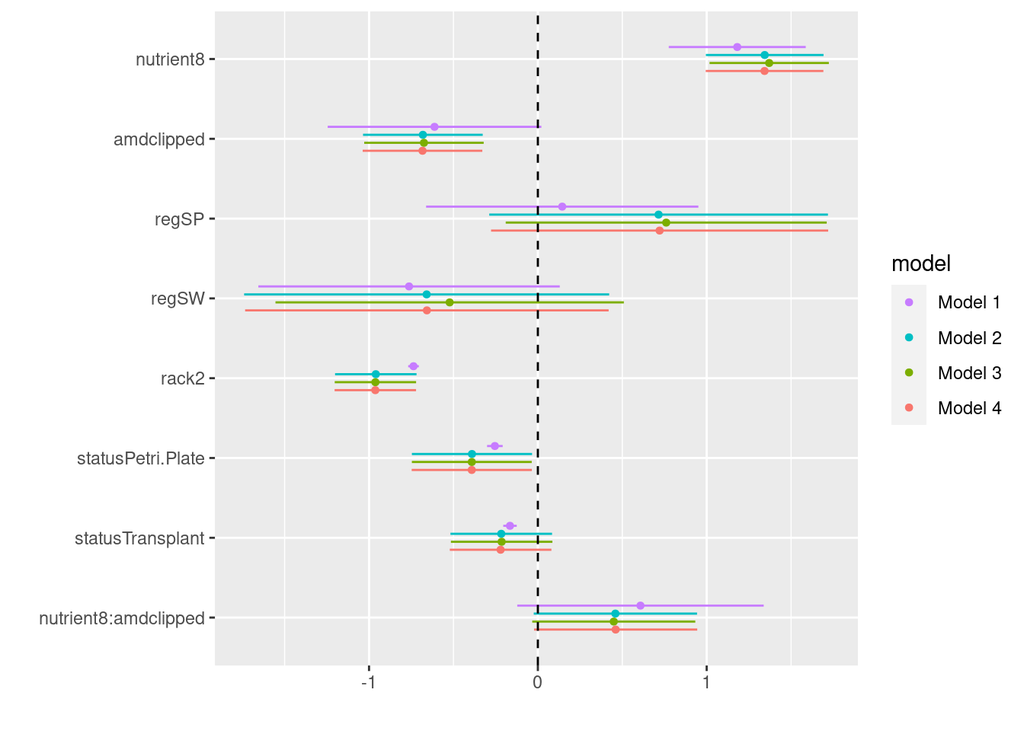

```r
dwplot(list(mp1,mp1X3,mp1X4,mp1X5),effect="fixed")+
    geom_vline(xintercept=0,lty=2)
```

## References

Barr, Dale J., Roger Levy, Christoph Scheepers, and Harry J. Tily. 2013. “Random Effects Structure for Confirmatory Hypothesis Testing: Keep It Maximal.” *Journal of Memory and Language* 68 (3): 255–78. https://doi.org/10.1016/j.jml.2012.11.001.

Bates, Douglas, Reinhold Kliegl, Shravan Vasishth, and Harald Baayen. 2015. “Parsimonious Mixed Models.” *arXiv:1506.04967 [Stat]*, June. http://arxiv.org/abs/1506.04967.

Matuschek, Hannes, Reinhold Kliegl, Shravan Vasishth, Harald Baayen, and Douglas Bates. 2017. “Balancing Type I Error and Power in Linear Mixed Models.” *Journal of Memory and Language* 94: 305–15. https://doi.org/10.1016/j.jml.2017.01.001.